# STATS 506 Group7 Project

Yan Chen, Aravind Mantravadi, Yingyi Yang

11/24/2020

# **Introduction**

## **Topic concepts**

Regression models tell us about the effect of predictor variables on the response variable, but to find out the effect of specific predictors on the response, we need to look at linear and non-linear combinations. Consider a regression model with response variable y and predictor variables x1, x2, x3 and x4. The regression model (without interactions) is:

$$y = \alpha + \beta1*x1 + \beta2*x2 + \beta3*x3 + \beta4*x4$$

If we want to make inferences about the effect x1 and x2 have on y, we need to create a linear combination of those variables

$y_{lc} = exp(\alpha + \beta1*x1 + \beta2*x2)$

Of course just an estimate by itself doesn’t tell us much, so we need to calculate standard errors, confidence intervals and p-values to know whether the effect is positive or negative and statistically significant. We can interpret the difference $exp(lc1) - exp(lc2)$ as the difference in expected value of the response variable (suicide count in this case), where $lc1$ and $lc2$ are linear combinations of the predictor variables

$$y_{lc} = \beta1*x1 + \beta2*x2$$

Of course just an estimate by itself doesn’t tell us much, so we need to calculate standard errors, confidence intervals and p-values to know whether the effect is positive or negative and statistically significant. Since the Poisson regression using a log-link function, the coefficients returned are log relative risk, we can interpret the difference $exp(lc1) - exp(lc2)$ as the difference in expected value of the response variable (suicide count in this case), where $lc1$ and $lc2$ are linear combinations of the predictor variables.

Similarly, we can interpret the nonlinear combination of regression coefficients, $exp(\beta1/\beta2)$ as the ratio of the expected value of the response variable, where $\beta1$ and $\beta2$ are regression coefficients. We can also have nonlinear transformation like $exp(\beta1 * \beta2)$ as the product of the coefficients.

## **Why is it useful?**

According to the World Health Organization (WHO), every year close to 800,000 people die due to suicide which is one person every 40 seconds. The results of survey conducted by WHO in 2016 shows that suicide the third leading cause of death in 15-19-year-olds. More than 79% of global suicides occurred in low and middle-income countries possibly due to pesticide self-poisoning in rural agricultural areas. Suicide is a global phenomenon and does not discriminate by age. The goal of this project is to demonstrate the use of Poisson regression in modeling suicide count data using demographic variables such as age and gender and make inferences on linear and non-linear combinations of regression coefficients.

For linear combinations, we will be comparing the effect of age, gender and year in three pairs, where each pair has two of the variables at the same level. We will be looking at the effect of:

1. 25-34 year old males in 2015 vs 25-34 year old males in 2005 on suicide count
2. 35-54 year old males in 2015 vs 35-54 year old females in 2015 on suicide count
3. 75+ males in 2015 vs 5-14 males in 2015 on suicide count

For non-linear combinations, we will look at the:

1. Ratio of coefficients of the variables “year 2000” and “year 2010”
2. Product of coefficients of the variables “male” and “year 2005” – this is like looking at the effect of an interaction term.

and draw inferences based on the estimates, confidence intervals and p-values obtained for each combination.

# **Outline**

This project mainly includes exploratory data analysis, model fitting, linear and nonlinear combination investigation using three statistical analysis tools: R, Python and Stata. The results are also visualized by the corresponding packages in these tools.

## **Data Description**

In this tutorial, we use the [1985-2016 Suicide Rates Overview Data](https://www.kaggle.com/russellyates88/suicide-rates-overview-1985-to-2016) which can be download from [Kaggle](https://www.kaggle.com). It is a compiled dataset pulled from four other datasets linked by time and place. It has 27820 records in total. The target variables we are going to analyze are:

`country`: country of the suicide records; 101 in total; countries in America and Europe occupy the majority

`year`: year of the suicide records; range from 1985-2016.

`sex`: male and female

`age`: age group of the suicide records; 6 groups: 5-14, 15-24, 25-34, 35-54, 55-74 and 75+

`suicides_no`: number of suicide

`population`: total population of a country with given sex and year

`gdp_per_capita`: GDP per capita ($)

## **Model fitting**

Since the response variable `suicides_no` is count based, we have fitted a Poisson regression model with `year`, `sex`, `age`, `gdp_per_capita` as the predictors. Basically, we want to maximize the joint likelihood function below

$$L(\beta) = \prod_{i=1}^n \frac{\lambda_i^{y_i} e^{-\lambda_i}}{y_i!}$$

where $\lambda_i$ is the event rate for ith sample and is calculated using the link function $\lambda_i = e^{x_i \beta}$.

The log-likelihood function for the Poisson regression model is

$$\ln L(\beta) = \sum_{i=1}^n (y_ix_i\beta-e^{x_i\beta}-\ln{y_i!})$$

After differentiating this log-likelihood equation with respect to $\beta$ and set to zero, we can get $\sum_{i=1}^n (y_i-e^{x_i\beta})x_i = 0$. Solving this equation for the regression coefficients $\beta$ will yield the Maximum Likelihood Estimate (MLE) for $\beta$.

## **Software and Tools used**

We will demonstrate our core example in 3 programming languages: R, Python and Stata.

### **R**

To fit a Poisson regression model, we use the glm function in R. We use `log(population)` as the offset, `year`, `sex`, `age`, `gdp_per_capita` as the predictor variables and `suicide_count` as the response variable.

While R has an `esticon` function in the `doBy` package that calculates estimates, standard errors, confidence intervals and p-values for the desired linear combination, we did them by hand (and verified them using `esticon`). The vcov() function came in handy to store the variance-covariance matrix of the regression model.

For non-linear combinations, we used the `msm` package’s `deltamethod` function to compute standard errors.

### **Python**

We use the glm function in Python statsmodels with `family=sm.families.Poisson()`, and use the logarithm of population as `offset` to fit the Poisson regression model.

For linear combination of the coefficients, the parameter estimates, standard errors and the confidence intervals are obtained by retrieving the paramter array and covariance matrix from the fitted model. The results of the two subgroups are visualized by `matplotlib.pyplot`. The non-linear combination of the coefficients are computed by delta method.

### **Stata**

We can fit the Poisson regression using `poisson` in Stata and use option `offset` to set an offset or use `exposure` which is equivalent to adding `offset(log_var)`. To get the estimated linear combination of coefficients, we can use `lincom`. It will output the point estimates, standard errors, t or z statistics, p-values, and confidence intervals. Or simply set the linear combination to the reference level and get the results from the output of `poisson` function. Similarly, we can use `nlcom` to get the results for non-linear combination of coefficients.

# **Core Analysis**

## R

```r
    ## The source code is in R/core_example.R ##
source('R/core_example.R')

    ## Create tables for the linear and non-linear combination data##

# 25-34 males, 2005 vs 2015 #
df1 = create_dataframe(male_25_34_2015, male_25_34_2005,
                       "25-34 Males, 2015", "25-34 Males, 2005")
df1 = round_df(df1, 5)

DT::datatable(df1)
```

|  | estimate | se | lower | upper | type |
| --- | --- | --- | --- | --- | --- |
| A | 0.00017 | 0 | 0.00017 | 0.00017 | 25-34 Males, 2015 |
| B | 0.00021 | 0 | 0.00021 | 0.00021 | 25-34 Males, 2005 |

```r
# 35-54 in 2015, male vs female #

df2 = create_dataframe(male_35_54_2015, female_35_54_2015,
                       "35-54 Males, 2015", "35-54 Females, 2015")

df2 = round_df(df2, 5)

DT::datatable(df2)
```

|  | estimate | se | lower | upper | type |
| --- | --- | --- | --- | --- | --- |
| A | 0.00022 | 0 | 0.00022 | 0.00022 | 35-54 Males, 2015 |
| B | 6e-05 | 0 | 6e-05 | 6e-05 | 35-54 Females, 2015 |

```r
# male in 2015, 75+ vs 5-14 #

df3 = create_dataframe(male_75_2015, male_5_14_2015,
                       "75+ Males, 2015", "5-14 Males, 2015")

df3 = round_df(df3, 5)
DT::datatable(df3)
```

|  | estimate | se | lower | upper | type |
| --- | --- | --- | --- | --- | --- |
| A | 0.00038 | 0 | 0.00038 | 0.00038 | 75+ Males, 2015 |
| B | 1e-05 | 0 | 1e-05 | 1e-05 | 5-14 Males, 2015 |

```r
## Create the non-linear combination  ##
full_df = round_df(full_df, 2)
DT::datatable(full_df)
```

|  | estimate | se | lower | upper | type |
| --- | --- | --- | --- | --- | --- |
| 1 | 1.09 | 0.01 | 1.08 | 1.1 | product |
| 2 | 0.12 | 0.02 | 0.09 | 0.16 | ratio |

## Python

### Data cleaning

First we download data and do preprocessing.

```python
url = "https://raw.githubusercontent.com/aravind1338/506F20GroupProject/main/master.csv"
df = pd.read_csv(url, index_col=0)

df.rename(columns = {"suicides/100k pop": "suicides_per_100k", "gdp_per_capita ($)": "gdp_per_capita"}, inplace=True)

df.reset_index(inplace = True)
```

### Analysis

```python
fml = "suicides_no ~ C(year) + C(sex) + C(age) + gdp_per_capita"
model = sm.GLM.from_formula(fml, offset=np.log(df['population']), data=df, family=sm.families.Poisson())
res = model.fit()
```

#### Linear Combination of Coefficient

```python
def lcom(var_list, coeffs, cov_matrix, alpha=0.05):
    # Function to calculate estimate, std error and confidence intervals
    # Inputs: var_list - a list of variables to compare (3 items expected)
    #         coeffs - the fitted coefficients of the model
    #         cov_matrix - the variance/covariance matrix of the parameter estimates
    # Output: a dataframe containing the estimate, std error, lower and upper limits
    #         for the linear combination

    trans_list = ['Intercept']
    coeffs_list = [coeffs['Intercept']]

    for name in var_list:
        if "age" in name:
            trans = "C(age)[T."+name[3:]+"]"
        elif "sex" in name:
            trans = "C(sex)[T."+name[3:]+"]"
        elif "year" in name:
            trans = "C(year)[T."+name[4:]+"]"
        if trans in coeffs.index:
            trans_list.append(trans)
            coeffs_list.append(coeffs[trans])

    linear_est = sum(coeffs_list)
    score = stats.t.ppf(1-alpha/2, res.df_resid)

    variance = 0
    for a, b in combinations_with_replacement(trans_list, 2):
        if a == b:
            variance += cov_matrix[a][b]
        else:
            variance += 2*cov_matrix[a][b]

    output = pd.DataFrame({"estimate": [np.exp(linear_est)],
                           "se": [np.exp(linear_est)*np.sqrt(variance)],
                           "lower": [np.exp(linear_est)-score*np.exp(linear_est)*np.sqrt(variance)],
                           "upper": [np.exp(linear_est)+score*np.exp(linear_est)*np.sqrt(variance)]})

    return output

def plot_comparison(var_list1, var_list2):
    # Function to generate bar plot of estimate and confidence interval
    # Inputs: var_list1 - a list of 3 variables to compare
    #         var_list2 - variable list with 1 different from var_list1

    common = list(set(var_list2).intersection(var_list1))

    df1 = lcom(var_list1, coeffs, cov_matrix, alpha=0.05)
    df1.index = list(set(var_list1)-set(common))
    df2 = lcom(var_list2, coeffs, cov_matrix, alpha=0.05)
    df2.index = list(set(var_list2)-set(common))
    df = df1.append(df2)

    est = np.array(df['estimate'])
    ci = np.array([df1[['lower','upper']].values[0], df2[['lower','upper']].values[0]])

    x_r = np.c_[est-ci[:,0],ci[:,1]-est].T
    plt.figure(figsize=(15,4))
    plt.barh(range(len(est)), est, xerr=x_r, fill=False, ecolor='r', capsize=20)
    plt.xlabel('Linear combination of coefficients (95% CI)')
    plt.yticks(range(len(est)), [str(lab) for lab in df.index])
    plt.title(str(common))
    plt.show()

    return df
```

##### Example 1

In this example, we are trying to figure out the linear combination of 25-34 years-old males in 2015 and linear combination of 25-34 years old males in 2005.

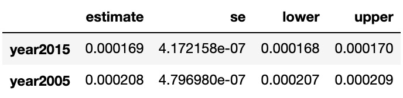

##### Example 2

In this example, we are trying to figure out the linear combination of 35-54 years-old males in 2015 and 35-54 years-old females in 2015.

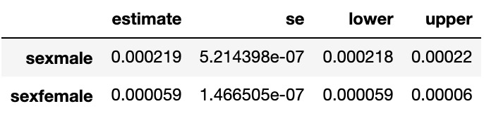

##### Example 3

In this example, we are trying to figure out the linear combination of 75+ years-old males in 2015 and 5-14 years-old males in 2015.

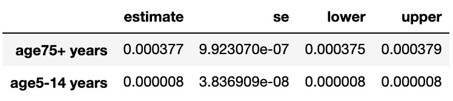

#### Non-linear Combination of Coefficient

In this part, we will implement delta method in function `nlcom`to compute the estimates, standard errors and 95% confidence intervals for non-linear combination of the fitted coefficients. The non-linear combination we have used is `ratio` and `product`.

```python
def nlcom(var_list, coeffs, cov_matrix, alpha=0.05, method="ratio"):
    # Function to calculate estimate, std error and confidence intervals
    # Inputs: var_list - a list of variables to compare (3 items expected)
    #         coeffs - the fitted coefficients of the model
    #         cov_matrix - the variance/covariance matrix of the parameter estimates
    #         method - nonlinear combination method
    # Output: a dataframe containing the estimate, std error, lower and upper limits
    #         for the linear combination

    trans_list = ['Intercept']
    coeffs_list = []

    for name in var_list:
        if "age" in name:
            trans = "C(age)[T."+name[3:]+"]"
        elif "sex" in name:
            trans = "C(sex)[T."+name[3:]+"]"
        elif "year" in name:
            trans = "C(year)[T."+name[4:]+"]"
        if trans in coeffs.index:
            trans_list.append(trans)
            coeffs_list.append(coeffs[trans])

    if method == 'product':
        beta1, beta2 = coeffs[trans_list[1]], coeffs[trans_list[2]]
        est = np.exp(beta1*beta2)
        G = np.matrix([0,est*beta2,est*beta1])
        V = cov_matrix[trans_list].loc[trans_list,:]
        vcov = np.matrix(V)
        se   = np.sqrt(G.dot(vcov).dot(G.T))
        score = stats.t.ppf(1-alpha/2, res.df_resid)
        ci_l = est - score*se[0,0]
        ci_u = est + score*se[0,0]

    if method == 'ratio':
        beta1, beta2 = coeffs[trans_list[1]], coeffs[trans_list[2]]
        est = np.exp(beta1/beta2)
        G = np.matrix([0,est*1./beta2,est*(-beta1/(beta2**2))])
        V = cov_matrix[trans_list].loc[trans_list,:]
        vcov = np.matrix(V)
        se   = np.sqrt(G.dot(vcov).dot(G.T))
        score = stats.t.ppf(1-alpha/2, res.df_resid)
        ci_l = est - score*se[0,0]
        ci_u = est + score*se[0,0]

    output = pd.DataFrame({"estimate": [est],
                           "se": [se[0,0]],
                           "lower": [ci_l],
                           "upper": [ci_u]})

    if method == 'product':
        output.index = ['product']
    if method == 'ratio':
        output.index = ['ratio']

    return output
```

##### Example 1

Ratio between year 2000 and year 2010:

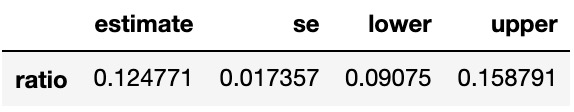

##### Example 2

Product between male and year 2005:

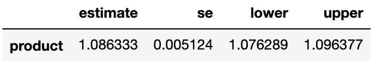

## Stata

### Data Cleaning

First we will get the data from url and clean the data.

```stata
* download and save data
local base_url ///
https://raw.githubusercontent.com/aravind1338/506F20GroupProject/main
import delimited `base_url'/master.csv, clear
keep ïcountry year sex age suicides_no population gdp_for_year

* rename variables
rename (ïcountry suicides_no gdp_for_year) ///
       (country count gdp)

* convert gender from str to binary
generate byte gender = 1 if sex == "male"
replace gender = 0 if sex == "female"
label define gender_label 0 "Female" 1 "Male" , replace
label values gender gender_label

* convert gdp to numeric
destring gdp, replace ignore(",")

* convert age from string to categorical
generate byte age_group=1 if age == "5-14 years"
replace age_group = 2 if age == "15-24 years"
replace age_group = 3 if age == "25-34 years"
replace age_group = 4 if age == "35-54 years"
replace age_group = 5 if age == "55-74 years"
replace age_group = 6 if age == "75+ years"
label define ag_label 1 "5-14 years" 2 "15-24 years" 3 "25-34 years" ///
                      4 "35-54 years" 5 "55-74 years" 6 "75+ years"
label values age_group ag_label

* drop columns
drop sex age

* save data
save cleaned.dta, replace
use cleaned, clear
```

We can have a look at the cleaned data:

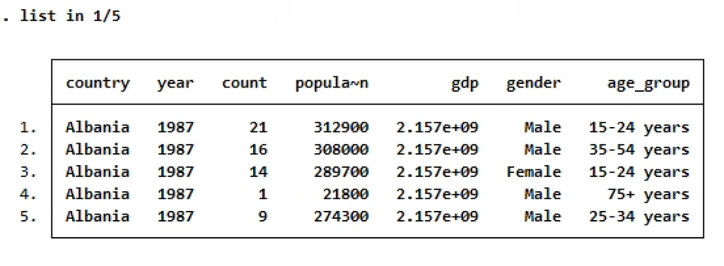

```stata
list in 1/5
```

### Summary Table

To take a glance of the data distributions related to variables gender and age group.

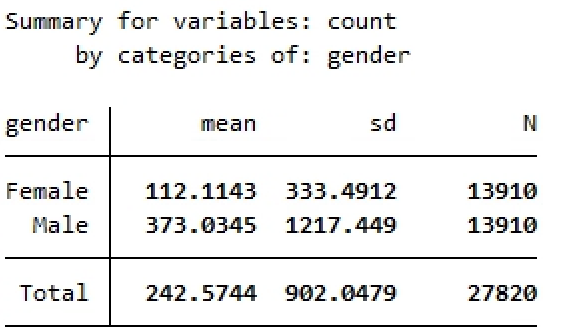

```stata
tabstat count, by(gender) stats(mean sd n)
```

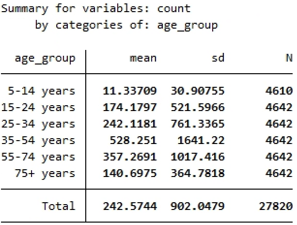

```stata
tabstat count, by(age_group) stats(mean sd n)
```

### Analysis

We can use function `poisson` to fit a Poisson regression model. Option `exposure(population)` means set log(population) as an offset. We can also use option `offset(log_population)`. Option `irr` means to present the regression results as incident rate ratios instead of log incident rate ratios.

#### Linear Commbination of Coefficient: example 1

In this example, we are trying to figure out the linear combination of coefficients 25-34 years-old males in 2015 and coefficient of 25-34 years-old males in 2005. We can change the base level to these two linear combinations separately and get the estimated baseline incidence rate from `_cons` in outputs and its se as well as CI.

To set the base level of Poisson regression model, we only need to specify the level between `ib` and `.var` in the poisson formula. For example, in the following example, I set the reference level of age group to be 25-34 which is coded as 3, I specify it as `ib3.age_group` in the formula.

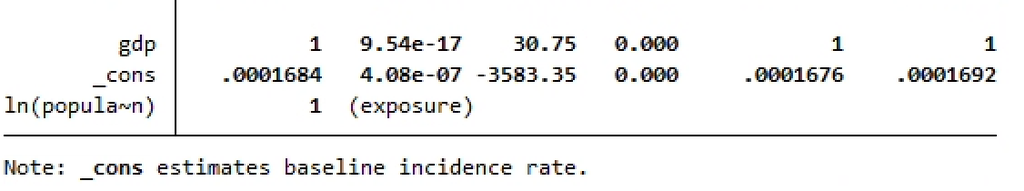

```stata
** 25-34 years-old males in 2015 vs 25-34 years-old males 2005;  different year
** Get the point estimates and CIs for two combinations separatly
*** 25-34 years-old males in 2015
poisson count ib3.age_group ib1.gender ib2015.year gdp, exposure(population) irr
```

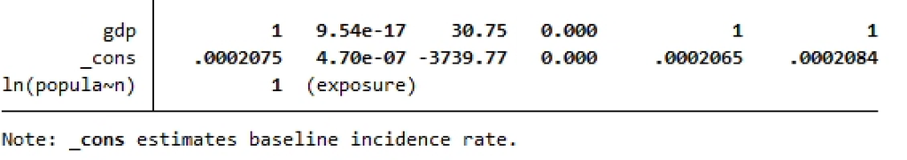

```stata
*** 25-34 years-old males in 2005
poisson count ib3.age_group ib1.gender ib2005.year gdp, exposure(population) irr
```

`_cons` estimate the baseline incidence rate and it will always appear at the almost end of the output. So I only cut the end parts of the output since it is too long to be fully shown here. The default levle of confidence interval is 95%, and we don’t specify it in our model.

```stata
// change the base level of age to 24-34 years-old and base level of gender to male and fit a Poisson model
poisson count ib3.age_group ib1.gender i.year gdp, exposure(population) irr
lincom 2015.year - 2005.year, irr
```

In order to make this project results consistent, I didn’t use `lincom` here since my group members found it was hard to do the same thing in R and Python. So we reached to an agreement that we only calculate the estimated linear combination of coefficients seperately.

#### Linear Combination of Coefficient: example 2

In this example, we are trying to figure out the linear combination of 35-54 years-old males in 2015 and 35-54 years-old females in 2015.

In default, the baseline level for gender is female.

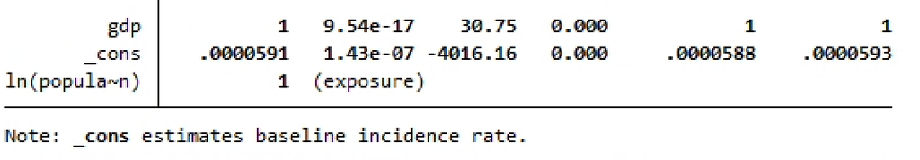

```stata
** 35-54 years-old males in 2015 vs 35-54 years-old  females 2015; different gender
** Get the point estimates and CIs for two combinations separatly
*** 35-54 years-old females in 2015
poisson count ib4.age_group i.gender ib2015.year gdp, exposure(population) irr
```

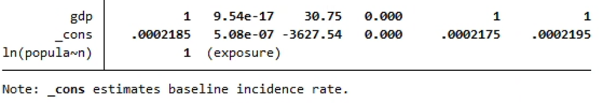

```stata
*** 35-54 years-old males in 2015
poisson count ib4.age_group ib1.gender ib2015.year gdp, exposure(population) irr
```

#### Linear Combination of Coefficient: example 3

In this example, we are trying to figure out the linear combination of 75+ years-old males in 2015 and 5-14 years-old males in 2015.

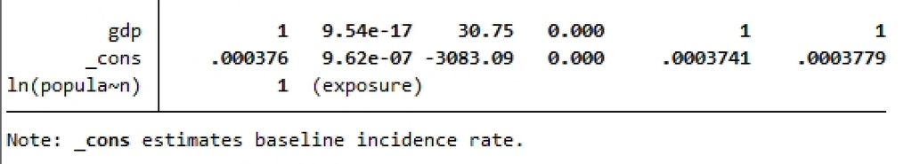

```stata
** 75+ years-old males in 2015 vs 5-14 years-old males in 2015; different age
** Get the point estimates and CIs for two combinations separatly
*** 75+ years-old males in 2015
poisson count ib6.age_group ib1.gender ib2015.year gdp, exposure(population) irr
```

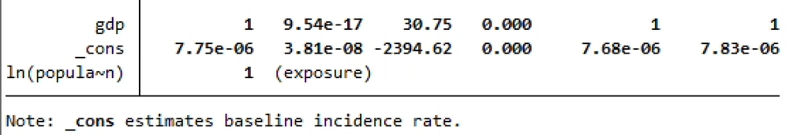

```stata
*** 5-14 years-old males in 2015
poisson count ib1.age_group ib1.gender ib2015.year gdp, exposure(population) irr
```

#### Non-linear Combination of Coefficient:

We may also curious about the non linear combinations such as products or ratio of two coefficients. We can use `nlcom` function. The notation `_b[name]` is the standard way in Stata to refer to regression coefficients. We can give the combination a name showing as below: I named this combination as `E_product` followed by a comma and then the expression.

We may also curious about the non-linear combinations such as products or ratios of two coefficients. We can use `nlcom` function. It takes nonlinear transformations of the estimated parameter vector from some fitted model and applies the delta method to calculate the variance, standard error, Wald test statistic, etc., of the transformations.

The notation `_b[name]` is the standard way in Stata to refer to regression coefficients. We can give the combination a name showing as below: I named this combination as `E_product` followed by a comma and then the expression.

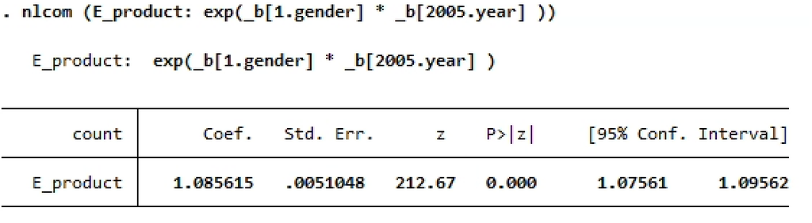

```stata
** Coefficient estimates of male * year_2015
poisson count ib2.age_group i.gender i.year gdp, exposure(population) irr
nlcom (E_product: exp(_b[1.gender] * _b[2005.year] ))
```

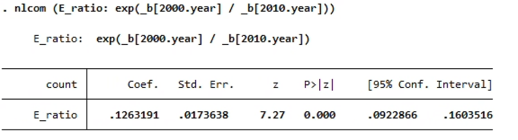

```stata
** Coefficient estimates of year_2000/year_2010
poisson count ib2.age_group i.gender i.year gdp, exposure(population) irr
nlcom (E_ratio: exp(_b[2000.year] / _b[2010.year]))
```

# **Conclusion/Discussion**

There are some slight differences in the standard errors of the non-linear combinations between R and Python; this is most likely because R used the msm package’s “deltamethod” function, while Python did the calculation manually. However, the differences are negligible (<0.005) and the estimates are the same.

From the examples presented in the three parallel sections, we can now draw some conclusions based on the linear combination of coefficients obtained by Possion regression model. First, males of 25-34 years old were less likely to commit suicide in 2015 compared to 10 years ago. Second, in 2015, males had higher suicide counts compared to females when they are both 35-54 years old. Finally, in 2015, males of 75+ years old had higher suicide counts than males of 5-14 years old.

We have also noticed that there are small discrepancies in the resulting standard errors across the three computation tools. The main reason may result from their difference in implementing delta method. In R and Python sections, the standard errors for linear combination of coefficients are also computed using delta method.

# **Reference**

`lincom` manual in Stata: https://www.stata.com/manuals13/rlincom.pdf#rlincom

`nlcom` manual in Stata: https://www.stata.com/manuals13/rnlcom.pdf

Inferences on Linear Combinations of Coefficients in R: https://murraylax.org/econometrics/notes/regression_lincom.pdf